# Not Always A Matter Of Context: Preliminary data summaries

Nicole LaGrange

Tania Delgado

Pamela Riviere

2017-11-16

**Paper.** Buechner and Maier (2016) Not always a matter of context: direct effects of red on arousal but context-dependent moderations on valence. *PeerJ*

**Summary.** This study aimed to determine whether colors have an intrinsic ability to elicit different degrees of physiological arousal, or whether their perceptual effects are dictated by the contextual circumstances in which the colors are experienced. To investigate this question, Buechner and Maier (2016) sorted subjects into one of *four experimental categories*. These categories consisted of assessing the arousal and valence properties of either:

- four “test-relevant” pictures framed in red
- four “test-relevant” pictures framed in blue
- four “neutral” pictures framed in red
- four “neutral” pictures framed in blue

To assess arousal, participants in each category were asked: “Describe how physiologically arousing do you think [the situation in this picture] is”. To assess valence, participants in each category were asked: “Describe how unpleasant do you think [the situation in this picture] is”. In response to each question, participants assigned each picture number from 1 (not at all) to 9 (extremely).

The dataframe contains rows of subjects with their corresponding assessement of a given picture as physically arousing or unpleasant (a measure of positive or negative valence)

```r
library(foreign)
library(dplyr)
library(tidyverse)

color_data_pr = read.csv("color_data_pr.csv")
```

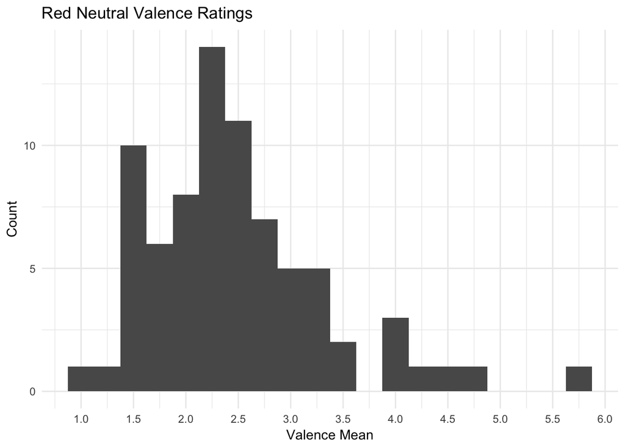

```r
color_data_pr %>% filter(color=='red', pic=='neu')  %>%
  ggplot(aes(x=Pic_valence_MEAN)) +
  geom_histogram(binwidth = .25) +
  scale_x_continuous(breaks=seq(0,6,.5)) +
  labs(title = 'Red Neutral Valence Ratings', x= 'Valence Mean', y= 'Count') +
  theme_minimal()
```

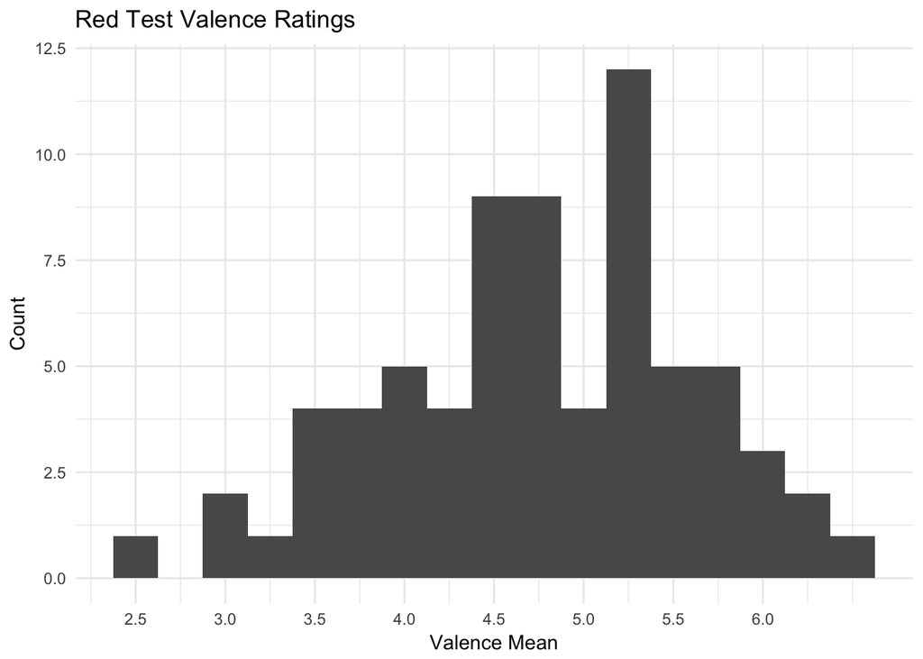

```r
color_data_pr %>% filter(color=='red', pic=='test')  %>%
  ggplot(aes(x=Pic_valence_MEAN)) +
  geom_histogram(binwidth = .25) +
  scale_x_continuous(breaks=seq(0,6,.5))+
  labs(title = 'Red Test Valence Ratings', x= 'Valence Mean', y= 'Count') +
  theme_minimal()
```